# Lab 7: Data Tidying, Transformation and Visualization with COVID-19 reporting Data

Author

Emily Kuang

```r
library(tidyverse)
library(lubridate)
library(ggplot2)
```

```r
 download.file(url="https://raw.githubusercontent.com/CSSEGISandData/COVID-19/master/csse_covid_19_data/csse_covid_19_time_series/time_series_covid19_confirmed_global.csv",
               destfile = "data/time_series_covid19_confirmed_global.csv")
```

```r
time_series_confirmed <- read_csv("data/time_series_covid19_confirmed_global.csv")|>
  rename(Province_State = "Province/State", Country_Region = "Country/Region")
```

# Exercise Examples

```r
time_series_confirmed_long <- time_series_confirmed |>
               pivot_longer(-c(Province_State, Country_Region, Lat, Long),
                            names_to = "Date", values_to = "Confirmed")
```

```r
time_series_confirmed_long$Date <- mdy(time_series_confirmed_long$Date)
```

## Making Graphs from the time series Data

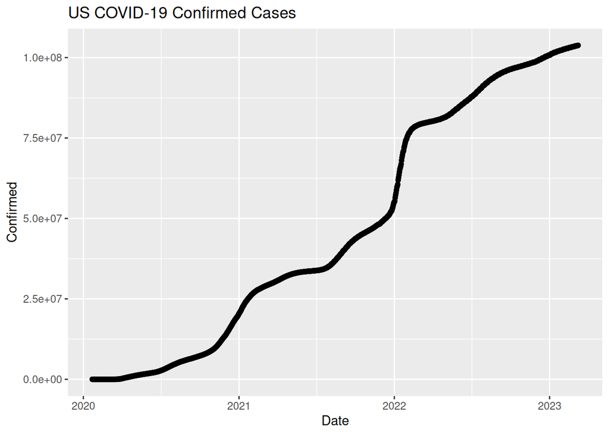

```r
time_series_confirmed_long|>
  group_by(Country_Region, Date) |>
  summarise(Confirmed = sum(Confirmed)) |>
  filter (Country_Region == "US") |>
  ggplot(aes(x = Date,  y = Confirmed)) +
    geom_point() +
    geom_line() +
    ggtitle("US COVID-19 Confirmed Cases")
```

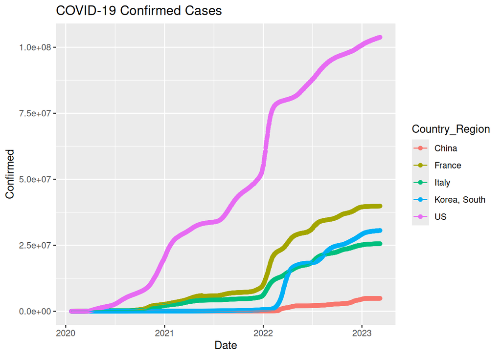

```r
time_series_confirmed_long |>
    group_by(Country_Region, Date) |>
    summarise(Confirmed = sum(Confirmed)) |>
    filter (Country_Region %in% c("China","France","Italy",
                                "Korea, South", "US")) |>
    ggplot(aes(x = Date,  y = Confirmed, color = Country_Region)) +
      geom_point() +
      geom_line() +
      ggtitle("COVID-19 Confirmed Cases")
```

```r
time_series_confirmed_long_daily <-time_series_confirmed_long |>
    group_by(Country_Region, Date) |>
    summarise(Confirmed = sum(Confirmed)) |>
    mutate(Daily = Confirmed - lag(Confirmed, default = first(Confirmed )))
```

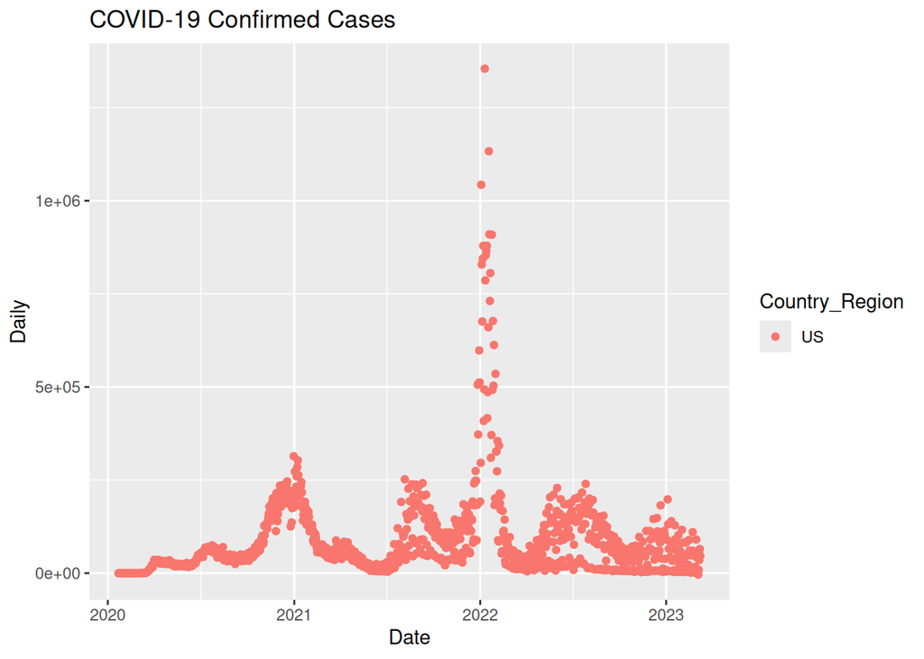

```r
time_series_confirmed_long_daily |>
    filter (Country_Region == "US") |>
    ggplot(aes(x = Date,  y = Daily, color = Country_Region)) +
      geom_point() +
      ggtitle("COVID-19 Confirmed Cases")
```

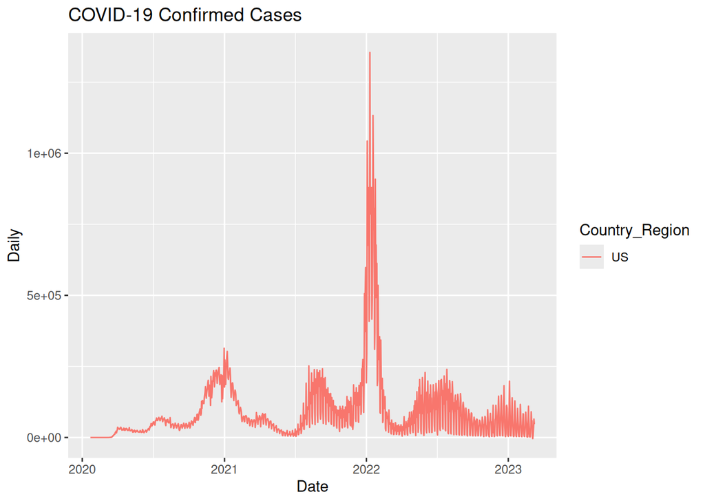

```r
time_series_confirmed_long_daily |>
    filter (Country_Region == "US") |>
    ggplot(aes(x = Date,  y = Daily, color = Country_Region)) +
      geom_line() +
      ggtitle("COVID-19 Confirmed Cases")
```

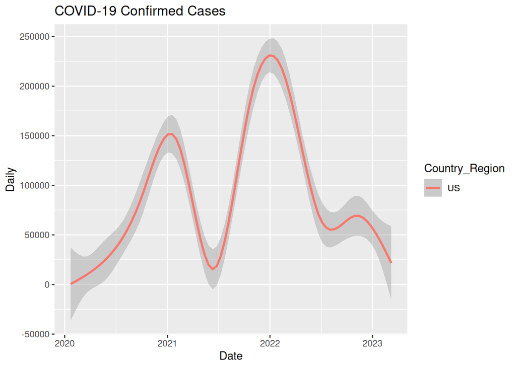

```r
time_series_confirmed_long_daily |>
    filter (Country_Region == "US") |>
    ggplot(aes(x = Date,  y = Daily, color = Country_Region)) +
      geom_smooth() +
      ggtitle("COVID-19 Confirmed Cases")
```

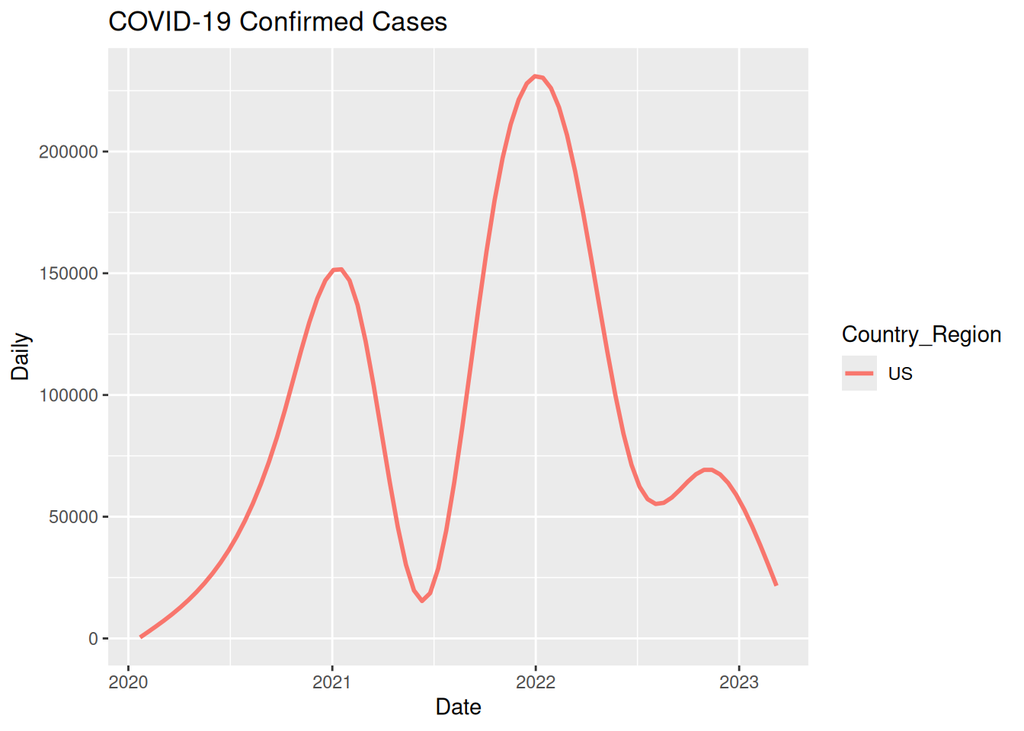

```r
time_series_confirmed_long_daily |>
    filter (Country_Region == "US") |>
    ggplot(aes(x = Date,  y = Daily, color = Country_Region)) +
      geom_smooth(method = "gam", se = FALSE) +
      ggtitle("COVID-19 Confirmed Cases")
```

## Animated Graphs with gganimate

```r
library(gganimate)
library(gifski)
theme_set(theme_bw())
```

```r
daily_counts <- time_series_confirmed_long_daily |>
      filter (Country_Region == "US")

p <- ggplot(daily_counts, aes(x = Date,  y = Daily, color = Country_Region)) +
        geom_point() +
        ggtitle("Confirmed COVID-19 Cases") +
# gganimate lines
        geom_point(aes(group = seq_along(Date))) +
        transition_reveal(Date)

# make the animation
 animate(p, renderer = gifski_renderer(), end_pause = 15)
```

[output not shown]

## Animation of confirmed deaths

```r
download.file(url="https://raw.githubusercontent.com/CSSEGISandData/COVID-19/master/csse_covid_19_data/csse_covid_19_time_series/time_series_covid19_deaths_global.csv",
  destfile = "data/time_series_covid19_deaths_global.csv")
```

```r
time_series_deaths_confirmed <- read_csv("data/time_series_covid19_deaths_global.csv")|>
  rename(Province_State = "Province/State", Country_Region = "Country/Region")

time_series_deaths_long <- time_series_deaths_confirmed |>
    pivot_longer(-c(Province_State, Country_Region, Lat, Long),
        names_to = "Date", values_to = "Confirmed")

time_series_deaths_long$Date <- mdy(time_series_deaths_long$Date)
```

```r
p <- time_series_deaths_long |>
  filter (Country_Region %in% c("US","Canada", "Mexico","Brazil","Egypt","Ecuador","India", "Netherlands", "Germany", "China" )) |>
  ggplot(aes(x=Country_Region, y=Confirmed, color= Country_Region)) +
    geom_point(aes(size=Confirmed)) +
    transition_time(Date) +
    labs(title = "Cumulative Deaths: {frame_time}") +
    ylab("Deaths") +
    theme(axis.text.x = element_text(angle = 45, vjust = 1, hjust=1))

animate(p, renderer = gifski_renderer(), end_pause = 15)
```

[output not shown]

# Exercises

### Exercise 1: Go through Chapter 5 in R for Data Sciences - Data Tiyding and Pivot

#### 5.2 Tidy Data

```r
table1 |>
  mutate(rate = cases / population * 10000)
```

```
# A tibble: 6 × 5
  country      year  cases population  rate
  <chr>       <dbl>  <dbl>      <dbl> <dbl>
1 Afghanistan  1999    745   19987071 0.373
2 Afghanistan  2000   2666   20595360 1.29
3 Brazil       1999  37737  172006362 2.19
4 Brazil       2000  80488  174504898 4.61
5 China        1999 212258 1272915272 1.67
6 China        2000 213766 1280428583 1.67
```

```r
table1 |>
  group_by(year) |>
  summarize(total_cases = sum(cases))
```

```
# A tibble: 2 × 2
   year total_cases
  <dbl>       <dbl>
1  1999      250740
2  2000      296920
```

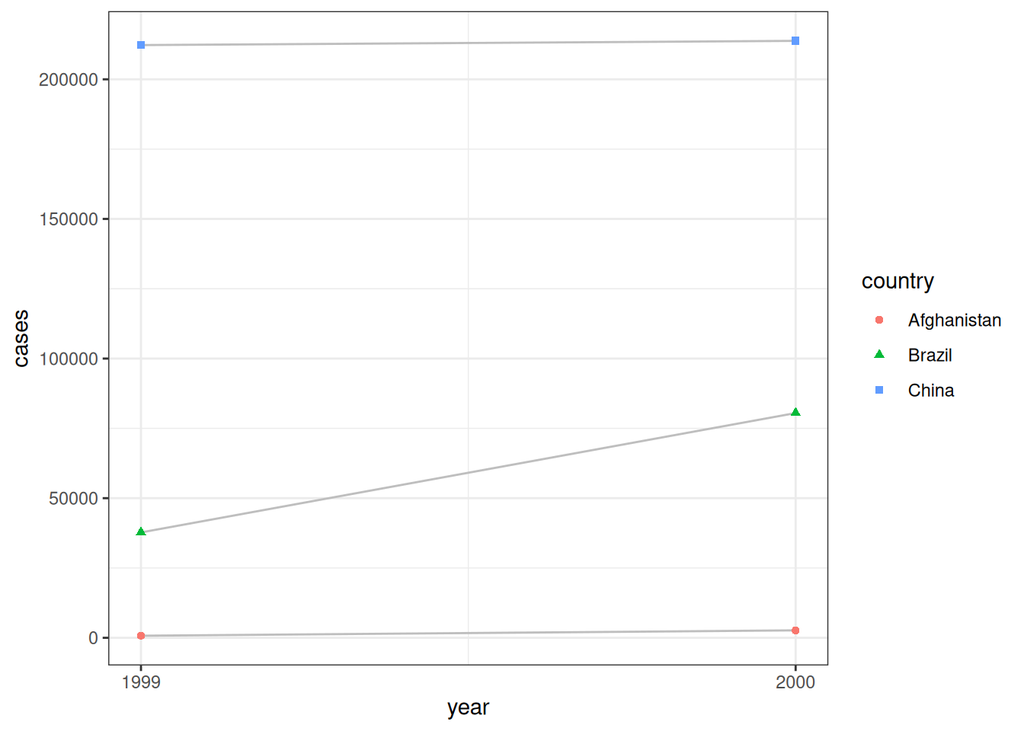

```r
ggplot(table1, aes(x = year, y = cases)) +
  geom_line(aes(group = country), color = "grey") +
  geom_point(aes(color = country, shape = country)) +
  scale_x_continuous(breaks = c(1999, 2000)) # x-axis breaks at 1999 and 2000
```

#### 5.2.1 Exercise

##### 1. For each of the sample tables, describe what each observation and each column represents.

```r
table1
```

```
# A tibble: 6 × 4
  country      year  cases population
  <chr>       <dbl>  <dbl>      <dbl>
1 Afghanistan  1999    745   19987071
2 Afghanistan  2000   2666   20595360
3 Brazil       1999  37737  172006362
4 Brazil       2000  80488  174504898
5 China        1999 212258 1272915272
6 China        2000 213766 1280428583
```

```r
table2
```

```
# A tibble: 12 × 4
   country      year type            count
   <chr>       <dbl> <chr>           <dbl>
 1 Afghanistan  1999 cases             745
 2 Afghanistan  1999 population   19987071
 3 Afghanistan  2000 cases            2666
 4 Afghanistan  2000 population   20595360
 5 Brazil       1999 cases           37737
 6 Brazil       1999 population  172006362
 7 Brazil       2000 cases           80488
 8 Brazil       2000 population  174504898
 9 China        1999 cases          212258
10 China        1999 population 1272915272
11 China        2000 cases          213766
12 China        2000 population 1280428583
```

```r
table3
```

```
# A tibble: 6 × 3
  country      year rate
  <chr>       <dbl> <chr>
1 Afghanistan  1999 745/19987071
2 Afghanistan  2000 2666/20595360
3 Brazil       1999 37737/172006362
4 Brazil       2000 80488/174504898
5 China        1999 212258/1272915272
6 China        2000 213766/1280428583
```

Table 1: The observations are representing the country and what year it is with number of TB cases and the total population in the country at the time. Each column represents country, year, cases, and population.

Table 2: The observations are the countries are oganized by cases and population with the year. It also gives the numerical value corresponding to cases or population. Each column represents country, year, type, count.

Table 3: The observations are the year for the country and the rate of TB by showing case/population. The columns represent country, year, and rate.

##### 2. Sketch out the process you’d use to calculate the rate for table2 and table3. You will need to perform four operations:

- Extract the number of TB cases per country per year.
- Extract the matching population per country per year.
- Divide cases by population, and multiply by 10000.
- Store back in the appropriate place.

  table2_cases <- table2 |>

  filter (type == “cases”) |>

  select (country, year, count)

  table2_population <-table2 |>

  select (country, year, count)

  All going into variable table2_cases_population
  - Combine the two of these results and mutate it so that we can have cases / population and multiply by 10000

table3 can be sorted into two columns of just cases and population. Since it’s set up as a fraction you would filter the number at the beginning as one column and the number after the slash as the second column. After this is done then you can calculate cases/population for all the columns at once.

#### 5.3 Lengthening Data

```r
billboard |>
  pivot_longer(
    cols = starts_with("wk"),
    names_to = "week",
    values_to = "rank"
  )
```

```
# A tibble: 24,092 × 5
   artist track                   date.entered week   rank
   <chr>  <chr>                   <date>       <chr> <dbl>
 1 2 Pac  Baby Don't Cry (Keep... 2000-02-26   wk1      87
 2 2 Pac  Baby Don't Cry (Keep... 2000-02-26   wk2      82
 3 2 Pac  Baby Don't Cry (Keep... 2000-02-26   wk3      72
 4 2 Pac  Baby Don't Cry (Keep... 2000-02-26   wk4      77
 5 2 Pac  Baby Don't Cry (Keep... 2000-02-26   wk5      87
 6 2 Pac  Baby Don't Cry (Keep... 2000-02-26   wk6      94
 7 2 Pac  Baby Don't Cry (Keep... 2000-02-26   wk7      99
 8 2 Pac  Baby Don't Cry (Keep... 2000-02-26   wk8      NA
 9 2 Pac  Baby Don't Cry (Keep... 2000-02-26   wk9      NA
10 2 Pac  Baby Don't Cry (Keep... 2000-02-26   wk10     NA
# ℹ 24,082 more rows
```

```r
billboard |>
  pivot_longer(
    cols = starts_with("wk"),
    names_to = "week",
    values_to = "rank",
    values_drop_na = TRUE
  )
```

```
# A tibble: 5,307 × 5
   artist  track                   date.entered week   rank
   <chr>   <chr>                   <date>       <chr> <dbl>
 1 2 Pac   Baby Don't Cry (Keep... 2000-02-26   wk1      87
 2 2 Pac   Baby Don't Cry (Keep... 2000-02-26   wk2      82
 3 2 Pac   Baby Don't Cry (Keep... 2000-02-26   wk3      72
 4 2 Pac   Baby Don't Cry (Keep... 2000-02-26   wk4      77
 5 2 Pac   Baby Don't Cry (Keep... 2000-02-26   wk5      87
 6 2 Pac   Baby Don't Cry (Keep... 2000-02-26   wk6      94
 7 2 Pac   Baby Don't Cry (Keep... 2000-02-26   wk7      99
 8 2Ge+her The Hardest Part Of ... 2000-09-02   wk1      91
 9 2Ge+her The Hardest Part Of ... 2000-09-02   wk2      87
10 2Ge+her The Hardest Part Of ... 2000-09-02   wk3      92
# ℹ 5,297 more rows
```

```r
billboard_longer <- billboard |>
  pivot_longer(
    cols = starts_with("wk"),
    names_to = "week",
    values_to = "rank",
    values_drop_na = TRUE
  ) |>
  mutate(
    week = parse_number(week)
  )
```

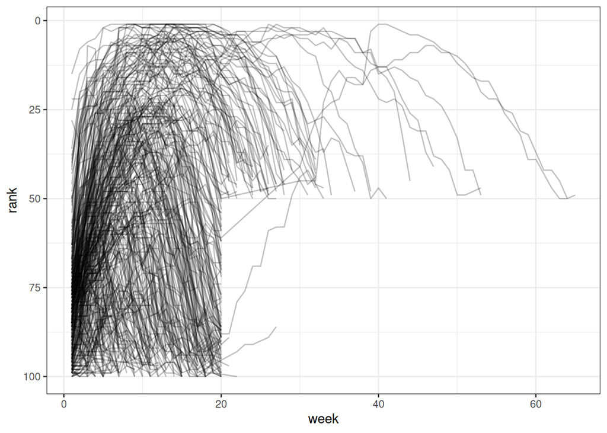

```r
billboard_longer |>
  ggplot(aes(x = week, y = rank, group = track)) +
  geom_line(alpha = 0.25) +
  scale_y_reverse()
```

```r
who2 |>
  pivot_longer(
    cols = !(country:year),
    names_to = c("diagnosis", "gender", "age"),
    names_sep = "_",
    values_to = "count"
  )
```

```
# A tibble: 405,440 × 6
   country      year diagnosis gender age   count
   <chr>       <dbl> <chr>     <chr>  <chr> <dbl>
 1 Afghanistan  1980 sp        m      014      NA
 2 Afghanistan  1980 sp        m      1524     NA
 3 Afghanistan  1980 sp        m      2534     NA
 4 Afghanistan  1980 sp        m      3544     NA
 5 Afghanistan  1980 sp        m      4554     NA
 6 Afghanistan  1980 sp        m      5564     NA
 7 Afghanistan  1980 sp        m      65       NA
 8 Afghanistan  1980 sp        f      014      NA
 9 Afghanistan  1980 sp        f      1524     NA
10 Afghanistan  1980 sp        f      2534     NA
# ℹ 405,430 more rows
```

```r
household |>
  pivot_longer(
    cols = !family,
    names_to = c(".value", "child"),
    names_sep = "_",
    values_drop_na = TRUE
  )
```

```
# A tibble: 9 × 4
  family child  dob        name
   <int> <chr>  <date>     <chr>
1      1 child1 1998-11-26 Susan
2      1 child2 2000-01-29 Jose
3      2 child1 1996-06-22 Mark
4      3 child1 2002-07-11 Sam
5      3 child2 2004-04-05 Seth
6      4 child1 2004-10-10 Craig
7      4 child2 2009-08-27 Khai
8      5 child1 2000-12-05 Parker
9      5 child2 2005-02-28 Gracie
```

#### 5.4 Widening Data

```r
cms_patient_experience |>
  distinct(measure_cd, measure_title)
```

```
# A tibble: 6 × 2
  measure_cd   measure_title
  <chr>        <chr>
1 CAHPS_GRP_1  CAHPS for MIPS SSM: Getting Timely Care, Appointments, and Infor…
2 CAHPS_GRP_2  CAHPS for MIPS SSM: How Well Providers Communicate
3 CAHPS_GRP_3  CAHPS for MIPS SSM: Patient's Rating of Provider
4 CAHPS_GRP_5  CAHPS for MIPS SSM: Health Promotion and Education
5 CAHPS_GRP_8  CAHPS for MIPS SSM: Courteous and Helpful Office Staff
6 CAHPS_GRP_12 CAHPS for MIPS SSM: Stewardship of Patient Resources
```

```r
cms_patient_experience |>
  pivot_wider(
    names_from = measure_cd,
    values_from = prf_rate
  )
```

```
# A tibble: 500 × 9
   org_pac_id org_nm           measure_title CAHPS_GRP_1 CAHPS_GRP_2 CAHPS_GRP_3
   <chr>      <chr>            <chr>               <dbl>       <dbl>       <dbl>
 1 0446157747 USC CARE MEDICA… CAHPS for MI…          63          NA          NA
 2 0446157747 USC CARE MEDICA… CAHPS for MI…          NA          87          NA
 3 0446157747 USC CARE MEDICA… CAHPS for MI…          NA          NA          86
 4 0446157747 USC CARE MEDICA… CAHPS for MI…          NA          NA          NA
 5 0446157747 USC CARE MEDICA… CAHPS for MI…          NA          NA          NA
 6 0446157747 USC CARE MEDICA… CAHPS for MI…          NA          NA          NA
 7 0446162697 ASSOCIATION OF … CAHPS for MI…          59          NA          NA
 8 0446162697 ASSOCIATION OF … CAHPS for MI…          NA          85          NA
 9 0446162697 ASSOCIATION OF … CAHPS for MI…          NA          NA          83
10 0446162697 ASSOCIATION OF … CAHPS for MI…          NA          NA          NA
# ℹ 490 more rows
# ℹ 3 more variables: CAHPS_GRP_5 <dbl>, CAHPS_GRP_8 <dbl>, CAHPS_GRP_12 <dbl>
```

```r
cms_patient_experience |>
  pivot_wider(
    id_cols = starts_with("org"),
    names_from = measure_cd,
    values_from = prf_rate
  )
```

```
# A tibble: 95 × 8
   org_pac_id org_nm CAHPS_GRP_1 CAHPS_GRP_2 CAHPS_GRP_3 CAHPS_GRP_5 CAHPS_GRP_8
   <chr>      <chr>        <dbl>       <dbl>       <dbl>       <dbl>       <dbl>
 1 0446157747 USC C…          63          87          86          57          85
 2 0446162697 ASSOC…          59          85          83          63          88
 3 0547164295 BEAVE…          49          NA          75          44          73
 4 0749333730 CAPE …          67          84          85          65          82
 5 0840104360 ALLIA…          66          87          87          64          87
 6 0840109864 REX H…          73          87          84          67          91
 7 0840513552 SCL H…          58          83          76          58          78
 8 0941545784 GRITM…          46          86          81          54          NA
 9 1052612785 COMMU…          65          84          80          58          87
10 1254237779 OUR L…          61          NA          NA          65          NA
# ℹ 85 more rows
# ℹ 1 more variable: CAHPS_GRP_12 <dbl>
```

Exercise 2: Instead of making a graph of 5 countries on the same graph as in the above example, use facet_wrap with scales=“free_y”.

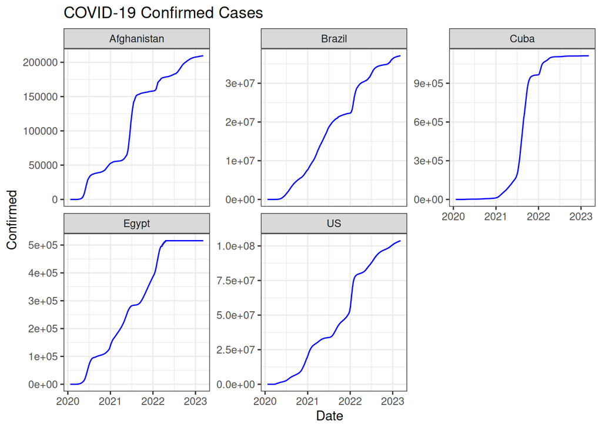

```r
five_countries <- c("US", "Afghanistan", "Brazil", "Cuba", "Egypt")

filtered_data <- time_series_confirmed_long |>
  filter(Country_Region %in% five_countries)

ggplot(filtered_data, aes(x = Date, y = Confirmed)) +
  geom_line(color = "blue") +
  facet_wrap(vars(Country_Region), scales = "free_y", ncol = 3) +
  ggtitle("COVID-19 Confirmed Cases")
```

### Exercise 3: Using the daily count of confirmed cases, make a single graph with 5 countries of your choosing.

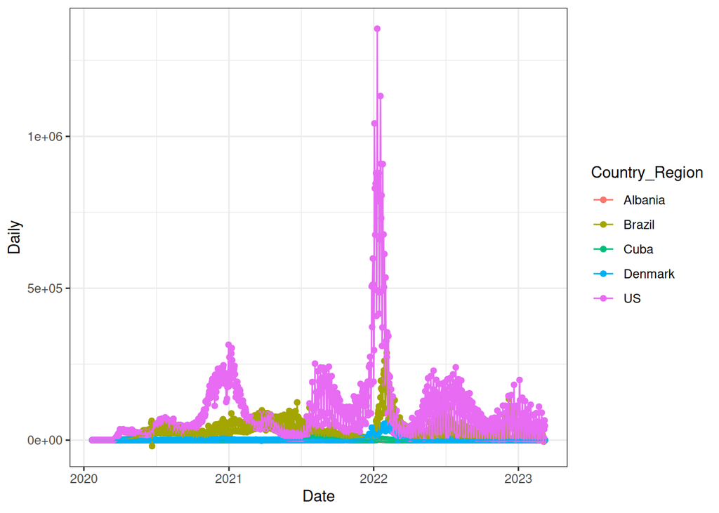

```r
time_series_confirmed_long_daily |>
    group_by(Country_Region) |>
    filter (Country_Region %in% c("Brazil","Denmark","US","Albania", "Cuba")) |>
    ggplot(aes(x = Date,  y = Daily, color = Country_Region)) +
      geom_point() +
      geom_line()
```

```r
      ggtitle("Daily Count of COVID-19 Confirmed Cases")
```

```
$title
[1] "Daily Count of COVID-19 Confirmed Cases"

attr(,"class")
[1] "labels"
```

### Exercise 4: Plot the cumulative deaths in the US, Canada and Mexico (you will need to download time_series_covid19_deaths_global.csv)

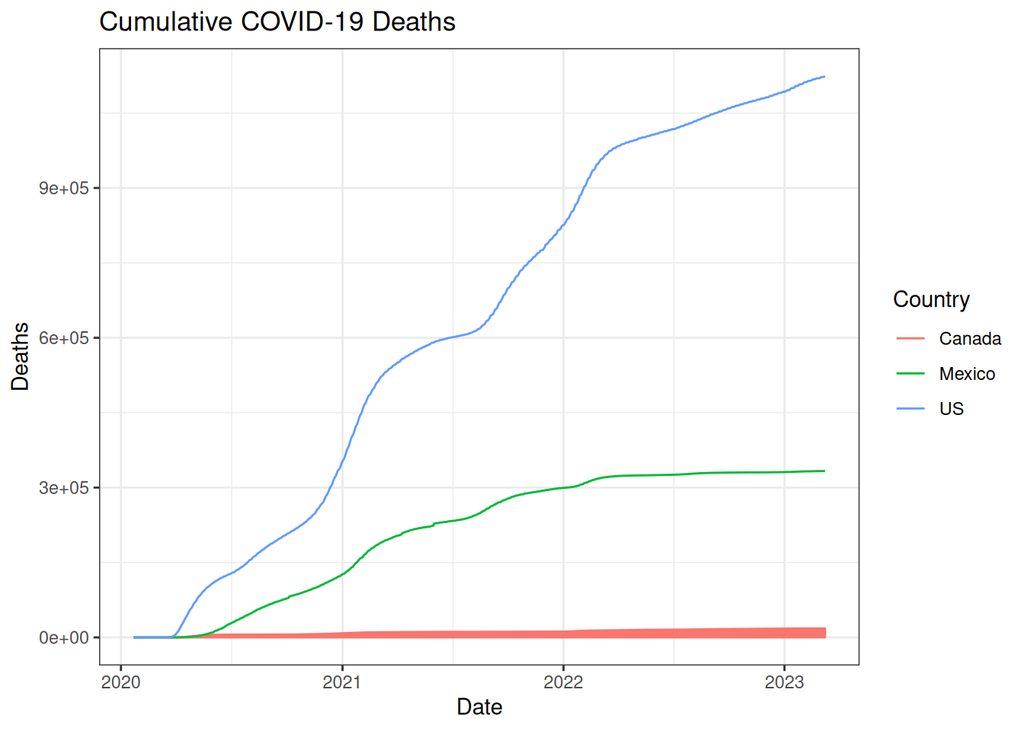

```r
time_series_deaths_long |>
  filter(Country_Region %in% c("US", "Canada", "Mexico")) |>
  ggplot(aes(x= Date, y= Confirmed, color= Country_Region)) +
  geom_line() +
  labs(title = "Cumulative COVID-19 Deaths",
       x = "Date", y = "Deaths", color = "Country")
```

### Exercise 5: Make a graph with the countries of your choice using the daily deaths data

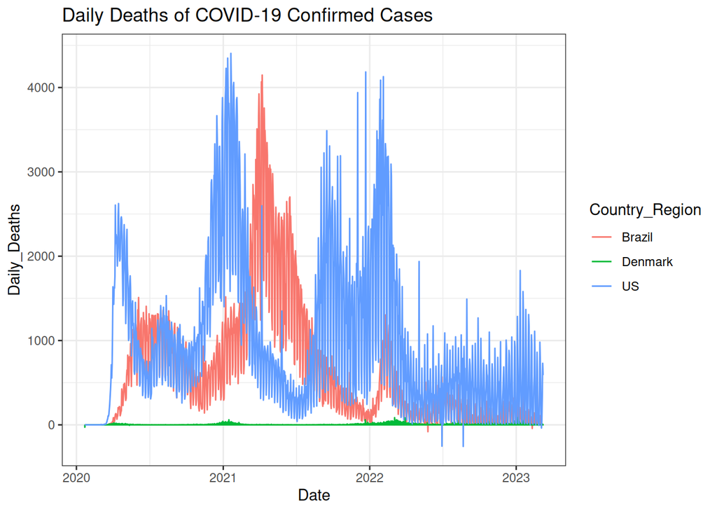

```r
time_series_deaths_long |>
  group_by(Country_Region) |>
  mutate(Daily_Deaths = Confirmed - lag(Confirmed, default = 0)) |>
  ungroup() |>
  filter(Country_Region %in% c("Brazil", "Denmark", "US"))|>

ggplot(aes(x = Date, y = Daily_Deaths, color = Country_Region)) +
  geom_line() +
  ggtitle("Daily Deaths of COVID-19 Confirmed Cases")
```

### Exercise 6: Make an animation of your choosing (do not use a graph with geom_smooth)

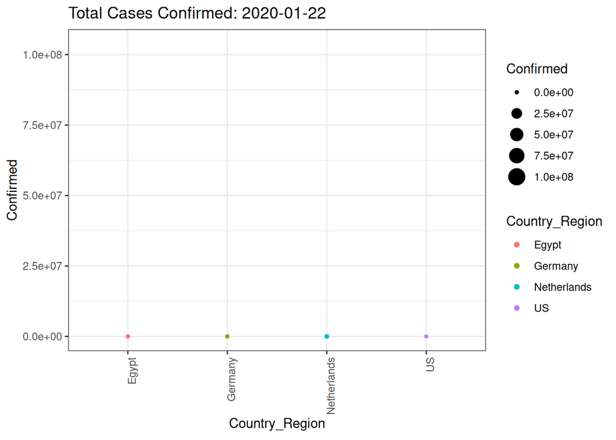

```r
p <- time_series_confirmed_long |>
  filter(Country_Region %in% c("US", "Germany", "Egypt", "Netherlands")) |>
  ggplot(aes(x=Country_Region, y=Confirmed, color = Country_Region)) +
  geom_point(aes(size = Confirmed)) +
  transition_time(Date) +
  labs(title = "Total Cases Confirmed: {frame_time}") +
  ylab("Confirmed") +
  theme(axis.text.x = element_text(angle=90, vjust = 1, hjust = 1))

animate(p, renderer = gifski_renderer(), end_pause = 13)
```